# Simulation Study: MSE of Fixed Effects Regression with Two Adoption Cohorts

## 1 Setup

This note studies the mean squared error of a two-way fixed effects regression,

$$y_{it} = \alpha_i + \lambda_t + \beta D_{it} + u_{it},$$

when treatment effects are heterogeneous across cohorts and over event time. The panel has two adoption cohorts plus a never-treated group:

- One third of units adopt in period 3.
- One third of units adopt in period 6.
- One third are never treated.

The MSE target is the average treatment effect over treated observations in each simulated panel,

$$\operatorname{ATT}^{\text{treated cells}} = \mathbb{E}[\tau_{it} \mid D_{it} = 1].$$

```python
import numpy as np
import pandas as pd
import matplotlib.pyplot as plt

from pyfixest.estimation import feols

plt.style.use("seaborn-v0_8-whitegrid")
pd.set_option("display.precision", 3)

SEED = 20260315
N_REP = 200
N_UNITS = 180
N_PERIODS = 10
EARLY_COHORT = 3
LATE_COHORT = 6
NEVER_TREATED = 999


def tau_it(event_time: int, cohort: int, severity: str) -> float:
    early = int(cohort == EARLY_COHORT)
    if severity == "mild":
        return 1.00 + 0.15 * early + 0.10 * event_time + 0.05 * early * event_time
    if severity == "severe":
        return 0.50 + 1.25 * early + 0.35 * event_time + 0.30 * early * event_time
    raise ValueError(f"Unknown severity: {severity}")


def make_panel(seed: int, severity: str) -> pd.DataFrame:
    rng = np.random.default_rng(seed)

    cohort = np.full(N_UNITS, NEVER_TREATED, dtype=int)
    cohort[: N_UNITS // 3] = EARLY_COHORT
    cohort[N_UNITS // 3 : 2 * N_UNITS // 3] = LATE_COHORT
    rng.shuffle(cohort)

    unit_fe = rng.normal(loc=0.0, scale=1.0, size=N_UNITS)
    time_fe = np.linspace(-0.4, 0.4, N_PERIODS) + rng.normal(0.0, 0.08, N_PERIODS)

    rows = []
    for unit in range(N_UNITS):
        g = cohort[unit]
        for time in range(N_PERIODS):
            treated = int(g != NEVER_TREATED and time >= g)
            event_time = time - g if g != NEVER_TREATED else -999
            effect = tau_it(event_time, g, severity) if treated else 0.0
            untreated = unit_fe[unit] + time_fe[time] + rng.normal(0.0, 1.0)
            rows.append(
                {
                    "unit": unit,
                    "time": time,
                    "cohort": g,
                    "treated": treated,
                    "tau": effect,
                    "y": untreated + effect,
                }
            )

    return pd.DataFrame(rows)


def fit_twfe(panel: pd.DataFrame) -> float:
    fit = feols("y ~ treated | unit + time", data=panel)
    return float(fit.coef().loc["treated"])


def run_simulation(n_rep: int = N_REP) -> pd.DataFrame:
    records = []
    for severity in ["mild", "severe"]:
        for rep in range(n_rep):
            panel = make_panel(seed=SEED + rep, severity=severity)
            beta_hat = fit_twfe(panel)
            true_att = panel.loc[panel["treated"] == 1, "tau"].mean()
            records.append(
                {
                    "severity": severity,
                    "rep": rep,
                    "beta_hat": beta_hat,
                    "true_att": true_att,
                    "error": beta_hat - true_att,
                    "sq_error": (beta_hat - true_att) ** 2,
                }
            )

    return pd.DataFrame(records)


def summarize_results(results: pd.DataFrame) -> pd.DataFrame:
    rows = []
    for severity, group in results.groupby("severity", sort=False):
        mean_beta = group["beta_hat"].mean()
        mean_truth = group["true_att"].mean()
        bias = group["error"].mean()
        variance = np.mean((group["beta_hat"] - mean_beta) ** 2)
        mse = group["sq_error"].mean()
        rows.append(
            {
                "scenario": severity.title(),
                "true_att": mean_truth,
                "mean_beta": mean_beta,
                "bias": bias,
                "variance": variance,
                "bias_sq": bias**2,
                "mse": mse,
                "rmse": np.sqrt(mse),
            }
        )

    return pd.DataFrame(rows)


def effect_profile() -> pd.DataFrame:
    rows = []
    for severity in ["mild", "severe"]:
        for cohort in [EARLY_COHORT, LATE_COHORT]:
            max_event = N_PERIODS - cohort - 1
            for event_time in range(max_event + 1):
                rows.append(
                    {
                        "severity": severity.title(),
                        "cohort": f"Adopt in t={cohort}",
                        "event_time": event_time,
                        "tau": tau_it(event_time, cohort, severity),
                    }
                )

    return pd.DataFrame(rows)


results = run_simulation()
summary = summarize_results(results)
profile = effect_profile()
summary.round(3)
```

|  | scenario | true_att | mean_beta | bias | variance | bias_sq | mse | rmse |
| --- | --- | --- | --- | --- | --- | --- | --- | --- |
| 0 | Mild | 1.436 | 1.224 | -0.213 | 0.008 | 0.045 | 0.053 | 0.231 |
| 1 | Severe | 2.727 | 1.656 | -1.072 | 0.008 | 1.149 | 1.157 | 1.076 |

## 2 Design

The untreated outcome satisfies

$$y_{it}(0) = \alpha_i + \lambda_t + \varepsilon_{it},$$

with independent unit effects, time effects, and noise. The two scenarios differ only in the treatment effect path:

- Mild heterogeneity: treatment effects differ modestly across cohorts and rise gradually with event time.
- Severe heterogeneity: the early cohort receives substantially larger and more rapidly growing effects than the late cohort.

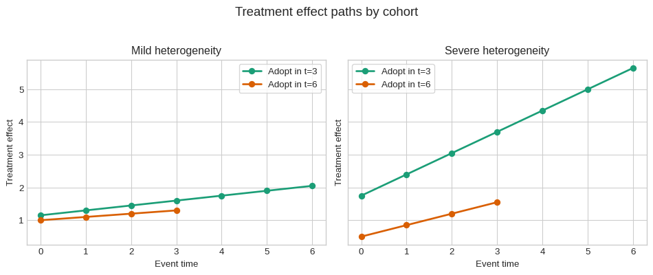

```python
fig, axes = plt.subplots(1, 2, figsize=(10, 4), sharey=True)
palette = {"Adopt in t=3": "#1b9e77", "Adopt in t=6": "#d95f02"}

for ax, severity in zip(axes, ["Mild", "Severe"]):
    subset = profile.loc[profile["severity"] == severity]
    for cohort, group in subset.groupby("cohort", sort=False):
        ax.plot(
            group["event_time"],
            group["tau"],
            marker="o",
            linewidth=2,
            color=palette[cohort],
            label=cohort,
        )
    ax.set_title(f"{severity} heterogeneity")
    ax.set_xlabel("Event time")
    ax.set_ylabel("Treatment effect")
    ax.legend(frameon=True)

fig.suptitle("Treatment effect paths by cohort", y=1.03, fontsize=14)
fig.tight_layout()
plt.show()
```

## 3 Results

The table below reports the average TWFE coefficient, its bias relative to the treated-cell ATT, the sampling variance of the estimator, and the resulting MSE.

```python
summary.round(3)
```

|  | scenario | true_att | mean_beta | bias | variance | bias_sq | mse | rmse |
| --- | --- | --- | --- | --- | --- | --- | --- | --- |
| 0 | Mild | 1.436 | 1.224 | -0.213 | 0.008 | 0.045 | 0.053 | 0.231 |
| 1 | Severe | 2.727 | 1.656 | -1.072 | 0.008 | 1.149 | 1.157 | 1.076 |

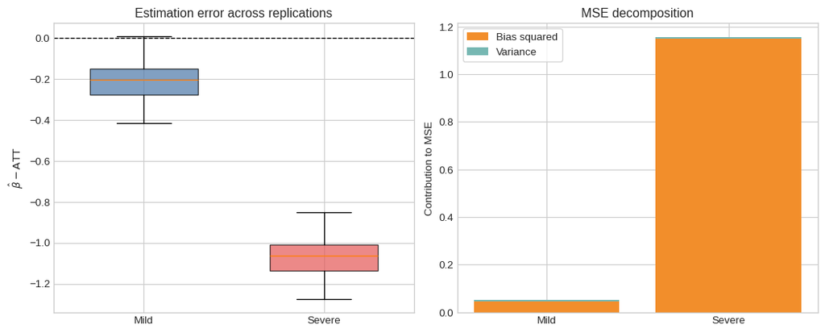

```python
fig, axes = plt.subplots(1, 2, figsize=(11, 4.5))
colors = {"Mild": "#4c78a8", "Severe": "#e45756"}

error_data = [
    results.loc[results["severity"] == "mild", "error"],
    results.loc[results["severity"] == "severe", "error"],
]

box = axes[0].boxplot(
    error_data,
    tick_labels=["Mild", "Severe"],
    patch_artist=True,
    widths=0.6,
)
for patch, label in zip(box["boxes"], ["Mild", "Severe"]):
    patch.set_facecolor(colors[label])
    patch.set_alpha(0.7)
axes[0].axhline(0.0, color="black", linestyle="--", linewidth=1)
axes[0].set_title("Estimation error across replications")
axes[0].set_ylabel(r"$\hat{\beta} - \mathrm{ATT}$")

x = np.arange(len(summary))
axes[1].bar(x, summary["bias_sq"], color="#f28e2b", label="Bias squared")
axes[1].bar(
    x,
    summary["variance"],
    bottom=summary["bias_sq"],
    color="#76b7b2",
    label="Variance",
)
axes[1].set_xticks(x, summary["scenario"])
axes[1].set_title("MSE decomposition")
axes[1].set_ylabel("Contribution to MSE")
axes[1].legend(frameon=True)

fig.tight_layout()
plt.show()
```

Under mild heterogeneity, the TWFE coefficient is still downward biased for the average treated-cell effect, but the distortion is limited. Under severe heterogeneity, the same regression misses the target by much more, and the MSE increase is driven mainly by bias rather than variance.

## 4 Takeaway

With two adoption cohorts, a simple fixed effects regression can have acceptable MSE when effect heterogeneity is mild, but its performance deteriorates quickly when cohort-specific and dynamic treatment effects diverge sharply. In this simulation, the main issue is not noise; it is that the TWFE estimand moves away from the average causal effect of interest as heterogeneity becomes stronger.